# Data project: How Horror Subgenres Perform in Ratings and Revenue

Author

Siwakorn Jiwawuttipong

```r
library(tidyverse)
library(gt)
horror_movies <- readr::read_csv("horror_movies.csv")
```

## Introduction

In this project I will be exploring how different horror subgenres perform in terms of audience ratings and financial success. My interest in this topic comes from personal experience, as one of my earliest memories of watching horror was the Thai horror comedy “How Taew Tak 1”. Watching it with my siblings made the experience both entertaining and memorable, and it shaped how I think about horror as a genre. Rather than being scary, horror movies can also be humorous, suspenseful and emotionally engaging, which raises the question of whether different subgenres are received differently by audiences.

Before begining my project I always wanted to learn why people such as myself enjoy horror movies, even though they are designed to create fear, which is typically a negative emotion which we tend to avoid.Based on my research, people enjoy horror movies because they create a mix of fear and excitement in a safe environment. While watching, the brain activates fear responses similar to real danger, but once the suspense ends, that fear turns into relief and pleasure. This balance of emotions helps explain why many viewers find horror movies thrilling rather than purely unpleasant.[^1]

In addition, I went and research on subgenres of horror film as well. The subgenres allow filmmakers to create different types of fear using various techniques such as suspense, jump scares, and psychological tension. Common horror subgenres include paranormal, monster, slasher, zombie, psychological, and comedic horror, each focusing on different sources of fear, from supernatural forces to human violence. The diversity of these subgenres helps explain why horror remains popular, as audiences can experience different emotional reactions depending on the style of horror being presented.[^2]

This means that horror is nto just one single experience, but a mix of a lot of different emotions and responses. As some subgenres appeal to audiences looking for tension and realism, while others attract viewers who enjoy humor or mystery. These differences help explain why horror remains such a popular genre.

From a data perspective, this question can be explored using variables such as average rating, vote count, and financial profit(Financial success was measured using profit, calculated as revenue minus budget.). These measures allow us to compare how different subgenres perform in terms of both audience evaluation and financial success.

As a result, my central question is:

**Do different horror subgenres show differences in ratings and financial success, and what does this reveal about audience responses to different types of horror?**

```r
glimpse(horror_movies)
```

```
Rows: 32,540
Columns: 20
$ id                <dbl> 760161, 760741, 882598, 756999, 772450, 1014226, 717…
$ original_title    <chr> "Orphan: First Kill", "Beast", "Smile", "The Black P…
$ title             <chr> "Orphan: First Kill", "Beast", "Smile", "The Black P…
$ original_language <chr> "en", "en", "en", "en", "es", "es", "en", "en", "en"…
$ overview          <chr> "After escaping from an Estonian psychiatric facilit…
$ tagline           <chr> "There's always been something wrong with Esther.", …
$ release_date      <date> 2022-07-27, 2022-08-11, 2022-09-23, 2022-06-22, 202…
$ poster_path       <chr> "/pHkKbIRoCe7zIFvqan9LFSaQAde.jpg", "/xIGr7UHsKf0URW…
$ popularity        <dbl> 5088.584, 2172.338, 1863.628, 1071.398, 1020.995, 93…
$ vote_count        <dbl> 902, 584, 114, 2736, 83, 1, 125, 1684, 73, 1035, 637…
$ vote_average      <dbl> 6.9, 7.1, 6.8, 7.9, 7.0, 1.0, 5.8, 7.0, 6.5, 6.8, 7.…
$ budget            <dbl> 0, 0, 17000000, 18800000, 0, 0, 20000000, 68000000, …
$ revenue           <dbl> 9572765, 56000000, 45000000, 161000000, 0, 0, 289259…
$ runtime           <dbl> 99, 93, 115, 103, 0, 0, 88, 130, 90, 106, 98, 89, 97…
$ status            <chr> "Released", "Released", "Released", "Released", "Rel…
$ adult             <lgl> FALSE, FALSE, FALSE, FALSE, FALSE, FALSE, FALSE, FAL…
$ backdrop_path     <chr> "/5GA3vV1aWWHTSDO5eno8V5zDo8r.jpg", "/2k9tBql5GYH328…
$ genre_names       <chr> "Horror, Thriller", "Adventure, Drama, Horror", "Hor…
$ collection        <dbl> 760193, NA, NA, NA, NA, NA, 94899, NA, NA, 950289, N…
$ collection_name   <chr> "Orphan Collection", NA, NA, NA, NA, NA, "Jeepers Cr…
```

## Preparing the data

After examining the data, I selected key variables related to genre, ratings, audience engagement, budget, and revenue, and removed zero values.

```r
horror_long <- horror_movies %>%
  select(title,
         genre_names,
         vote_average,
         vote_count,
         budget,
         revenue) %>%
  filter(vote_average > 0,
       vote_count > 0,
       budget > 0,
       revenue > 0) %>%
  separate_rows(genre_names, sep = ", ")

count(horror_long, genre_names, sort = TRUE)
```

```
# A tibble: 19 × 2
   genre_names         n
   <chr>           <int>
 1 Horror           1037
 2 Thriller          509
 3 Mystery           234
 4 Science Fiction   199
 5 Comedy            156
 6 Drama             152
 7 Action            123
 8 Fantasy           121
 9 Crime              56
10 Adventure          45
11 Romance            23
12 Music               6
13 Animation           5
14 Family              4
15 History             4
16 War                 3
17 Western             2
18 Documentary         1
19 TV Movie            1
```

Since many movies belong to multiple genres, a single film may appear in more than one subgenre. To account for this,I used `separate_rows()` to split the genre column so that each film could be analyzed across its listed subgenres.This allows each subgenre to be analyzed individually, although it also means that observations are not completely independent. To keep the analysis clear and focused, I then restricted the dataset to the six most common subgenres.

```r
top_genres <- horror_long %>%
  count(genre_names, sort = TRUE) %>%
  slice_head(n = 6)

horror_plot <- horror_long %>%
  filter(genre_names %in% top_genres$genre_names)
```

To measure financial success, I also created a profit variable by subtracting budget from revenue.

```r
horror_plot_profit <- horror_plot %>%
  filter(!is.na(budget),
         !is.na(revenue)) %>%
  mutate(
    profit = revenue - budget,
    profit_mil = profit / 1e6
  )
horror_clean <- horror_plot_profit %>%
  filter(profit_mil > 1,
         profit_mil < 300)
count(horror_clean, genre_names, sort = TRUE)
```

```
# A tibble: 6 × 2
  genre_names         n
  <chr>           <int>
1 Horror            595
2 Thriller          313
3 Mystery           139
4 Science Fiction   107
5 Drama              76
6 Comedy             72
```

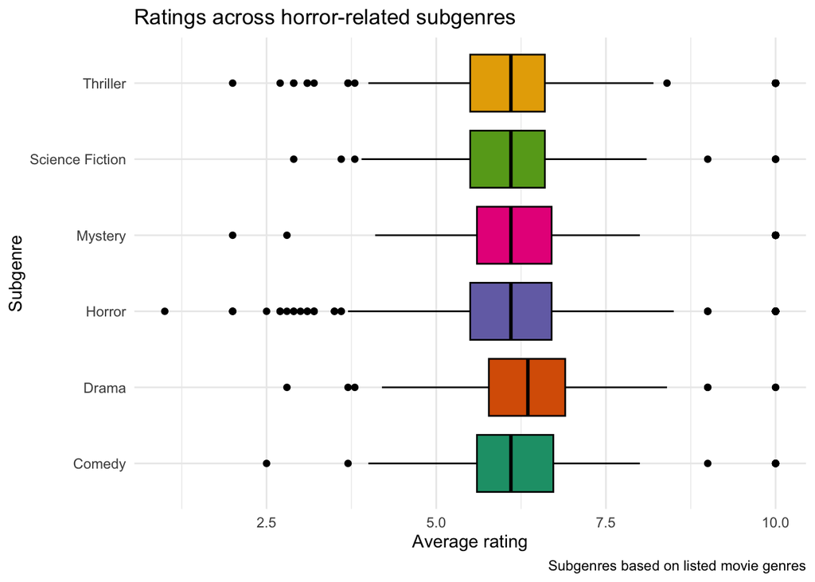

```r
horror_plot %>%
  ggplot(aes(x = vote_average,
             y = genre_names,
             fill = genre_names)) +
  geom_boxplot(show.legend = FALSE, color = "black") +
  scale_fill_brewer(palette = "Dark2") +
  labs(
    title = "Ratings across horror-related subgenres",
    x = "Average rating",
    y = "Subgenre",
    caption = "Subgenres based on listed movie genres"
  ) +
  theme_minimal()
```

## FIGURE 2

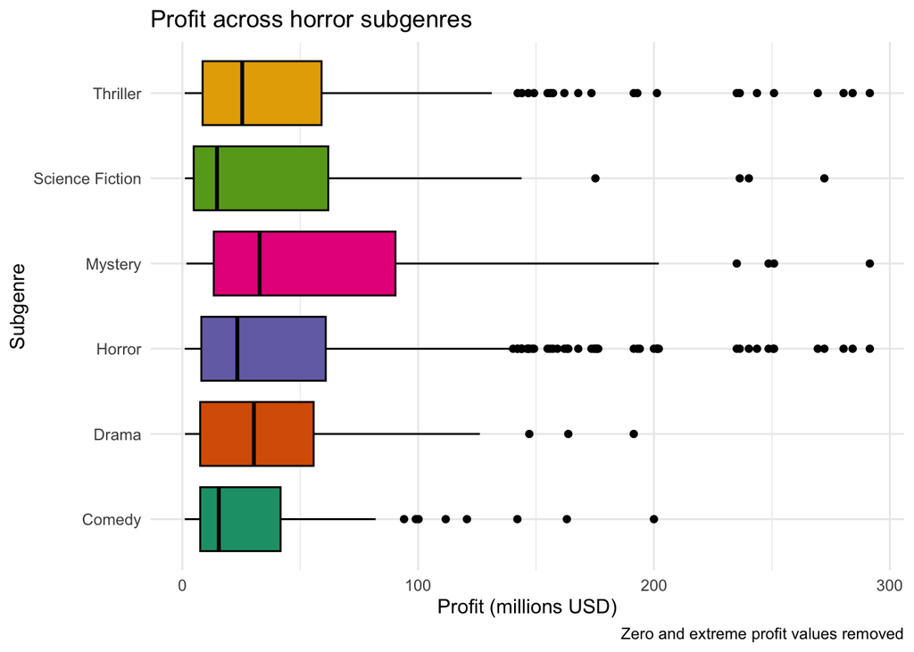

```r
horror_clean %>%
  ggplot(aes(x = profit_mil,
             y = genre_names,
             fill = genre_names)) +
  geom_boxplot(show.legend = FALSE, color = "black") +
  scale_fill_brewer(palette = "Dark2") +
  labs(
    title = "Profit across horror subgenres",
    x = "Profit (millions USD)",
    y = "Subgenre",
    caption = "Zero and extreme profit values removed"
  ) +
  theme_minimal()
```

```r
horror_clean %>%
  group_by(genre_names) %>%
  summarize(
    avg_rating = mean(vote_average, na.rm = TRUE),
    avg_votes = mean(vote_count, na.rm = TRUE),
    median_profit_mil = median(profit_mil, na.rm = TRUE),
    movies = n()
  ) %>%
  gt() %>%
  fmt_number(columns = c(avg_rating, median_profit_mil),
             decimals = 2)
```

| genre_names | avg_rating | avg_votes | median_profit_mil | movies |
| --- | --- | --- | --- | --- |
| Comedy | 6.23 | 1510.903 | 15.45 | 72 |
| Drama | 6.29 | 1978.513 | 30.35 | 76 |
| Horror | 6.14 | 1778.044 | 23.31 | 595 |
| Mystery | 6.21 | 2116.698 | 32.74 | 139 |
| Science Fiction | 6.19 | 1686.495 | 14.70 | 107 |
| Thriller | 6.09 | 1774.537 | 25.40 | 313 |

The summary table shows that average ratings are very similar across all subgenres, mostly falling between about 6.0 and 6.3. This suggests that audiences tend to rate horror movies similarly, regardless of the subgenre. Financial performance, however, varies more. Subgenres like Mystery and Drama tend to have higher typical profits, while Comedy and Science Fiction are generally lower. Here I use `fmt_number()` to round selected columns to 2 decimal places, as I learned that it formats values to make tables easier to read.

However, these results should be interpreted with caution. Since many films belong to multiple genres, the same movie may be counted in more than one category, meaning the observations are not fully independent. Additionally, profit can be influenced by factors not captured in the dataset, such as marketing or release timing which may explain some of the variation observed across subgenres. Another limitation is the difference in the number of films across subgenres, as some categories contain significantly more movies than others, which may affect the reliability of the comparisons.

## Figure 3(Additional plots)

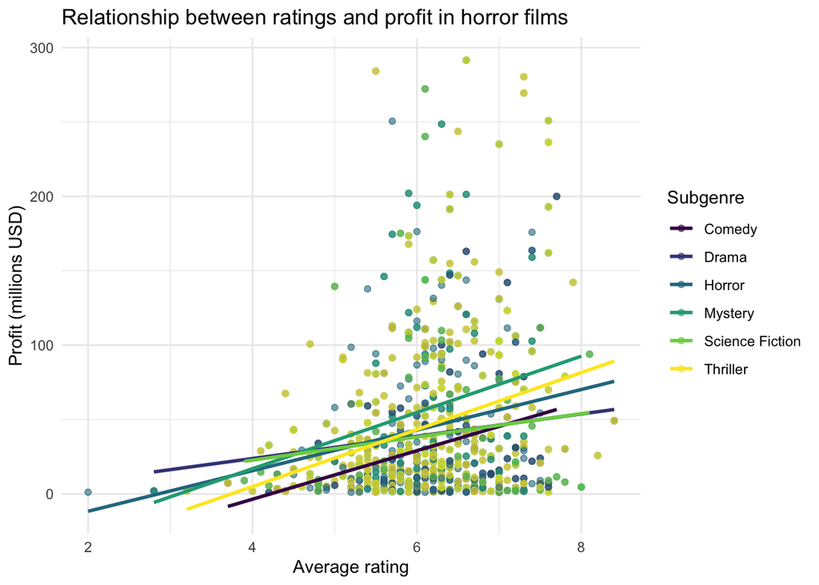

```r
horror_clean %>%
  ggplot(aes(x = vote_average,
             y = profit_mil,
             color = genre_names)) +
  geom_point(alpha = 0.6) +
  geom_smooth(method = "lm", se = FALSE) +
  scale_color_viridis_d() +
  labs(
    title = "Relationship between ratings and profit in horror films",
    x = "Average rating",
    y = "Profit (millions USD)",
    color = "Subgenre"
  ) +
  theme_minimal()
```

Alt text Figure 3: Scatterplot showing the relationship between average rating and profit (in millions USD) across horror-related subgenres. There is a slight upward trend, indicating a weak positive relationship, but the points are widely scattered, showing that profit varies greatly at all rating levels.Here I use `scale_color_viridis_d()` because I wanted to try a different colorblind friendly palette and improve readability.This is because the viridis color palette is designed to be uniform, meaning differences in values are shown clearly and consistently.[^3]

The graph suggests a weak positive relationship between ratings and profit, meaning that higher-rated films may earn slightly more on average. However, the relationship is not very strong, as there is considerable variation in profit at all rating levels. This indicates that factors beyond ratings play a significant role in determining financial success. While some subgenres, such as Thriller and Mystery, appear to show a slightly stronger upward trend, overall profitability cannot be explained by ratings alone.

## Footnotes

[^1]: Shelby Bradford and Priyom Bose, “Why Do We Like Horror Movies?,” *The Scientist*, October 14, 2024, https://www.the-scientist.com/why-do-some-people-enjoy-horror-movies-72181.
[^2]: “Subgenres of Horror Films Explained,” *The Los Angeles Film School*, https://www.lafilm.edu/blog/subgenres-of-horror-films/.
[^3]: Source: https://cran.r-project.org/web/packages/viridis/vignettes/intro-to-viridis.html